# ZOO955 - Autocorrelation

#### Distance matrix

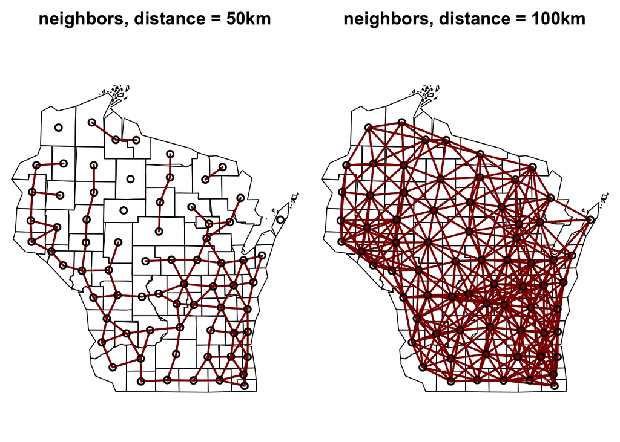

```r
par(mfrow=c(1,2),mar=c(0,0,2,0))
# Distance = 50 km
d50 =  dnearneigh(xy, d1 = 0, d2 = 50000, row.names = counties$OBJECTID)
plot(cSimp, main='neighbors, distance = 50km')
plot(d50, xy, col='red4', add=TRUE, lwd=2)

# Distance = 100 km
d100 =  dnearneigh(xy, d1 = 0, d2 = 100000, row.names = counties$OBJECTID)
plot(cSimp, main='neighbors, distance = 100km')
plot(d100, xy, col='red4', add=TRUE, lwd=2)
```

### Transform w into a spatial weights matrix.

A spatial weights matrix reflects the intensity of the geographic relationship between observations

```r
wm.w <- nb2mat(w, style='B')
wm.w[1:10,1:10]
```

```
##    [,1] [,2] [,3] [,4] [,5] [,6] [,7] [,8] [,9] [,10]
## 1     0    0    0    1    0    1    0    0    0     0
## 2     0    0    0    0    1    0    0    0    1     0
## 3     0    0    0    1    1    0    1    0    0     0
## 4     1    0    1    0    0    1    1    1    0     0
## 5     0    1    1    0    0    0    0    0    1     0
## 6     1    0    0    1    0    0    0    1    0     1
## 7     0    0    1    1    0    0    0    1    0     0
## 8     0    0    0    1    0    1    1    0    0     1
## 9     0    1    0    0    1    0    0    0    0     0
## 10    0    0    0    0    0    1    0    1    0     0
```

### Compute Moran’s I

```r
wm.w <-  nb2listw(w, style='B')
wm.w
```

```
## Characteristics of weights list object:
## Neighbour list object:
## Number of regions: 72
## Number of nonzero links: 370
## Percentage nonzero weights: 7.137346
## Average number of links: 5.138889
##
## Weights style: B
## Weights constants summary:
##    n   nn  S0  S1   S2
## B 72 5184 370 740 8352
```

```r
wm.k4 <- nb2listw(k4, style='B')
wm.k2 <- nb2listw(k2, style='B')

wm.d50 <- nb2listw(d50, style='B',zero.policy = T)
wm.d100 <- nb2listw(d100, style='B',zero.policy = T)
```

#### Now we can use the moran function.

- x = a numeric vector the same length as the neighbours list in listw
- listw = a listw object created for example by nb2listw
- n = number of zones
- S0 = global sum of weights

```r
moran(x = counties$water,listw = wm.w, n=length(wm.w$neighbours), S0=Szero(wm.w))
moran(x = counties$water,listw = wm.k4, n=length(wm.k4$neighbours), S0=Szero(wm.k4))
moran(x = counties$water,listw = wm.k2, n=length(wm.k2$neighbours), S0=Szero(wm.k2))
moran(x = counties$water,listw = wm.d50, n=length(wm.d50$neighbours), S0=Szero(wm.d50),zero.policy = T)
moran(x = counties$water,listw = wm.d100, n=length(wm.d100$neighbours), S0=Szero(wm.d100),zero.policy = T)
```

[output not shown]

- Computes the mean and variance for the attribute being evaluated.
- For each value, it subtracts the mean, creating a deviation from the mean.
- Deviation values for all neighboring features (created via methods above) are multiplied together to create a cross-product.
  - When values for neighboring features are either both larger than the mean or both smaller than the mean, the cross-product will be positive.
  - If the values in the dataset tend to cluster spatially (high values cluster near other high values; low values cluster near other low values), the Moran’s Index will be positive.
- The more neighbors an area has, the higher likelihood the cross-product will be close to zero

#### Test for significance

First analytically, using linear regression based logic and assumptions.

```r
moran.test(counties$water, wm.w, randomisation=FALSE)
```

**p-value = 0.00733**

#### But should probably use Monte Carlo simulation instead.

Values are randomly assigned to the polygons, and the Moran’s I is computed. This is repeated several times to establish a distribution of expected values. The observed value of Moran’s I is then compared with the simulated distribution to see how likely it is that the observed values could be considered a random draw.

```r
moran.mc(counties$water, wm.w, nsim=99)
```

**p-value = 0.01**

```r
moran.test(counties$water, wm.w, randomisation=FALSE)
moran.test(counties$water, wm.k4, randomisation=FALSE)
moran.test(counties$water, wm.k2, randomisation=FALSE)
moran.test(counties$water, wm.d50, randomisation=FALSE,zero.policy = T)
moran.test(counties$water, wm.d100, randomisation=FALSE)

moran.mc(counties$water, wm.w, nsim=999)
moran.mc(counties$water, wm.k4, nsim=999)
moran.mc(counties$water, wm.k2, nsim=999)
moran.mc(counties$water, wm.d50, nsim=999,zero.policy = T)
moran.mc(counties$water, wm.d100, nsim=999)
```

[output not shown]

Null hypothesis = attribute being analyzed is randomly distributed among the features in your study area

### Discussion

How would you expect the spatial autocorrelation of %water to change as you decreased or increased the resolution of the underlying raster data?

### Homework

1. Find an example of negative spatial autocorrelation in ecology
2. Use the county and NLCD datasets for WI. Compute Moran’s I and p-value (using adjacent polygons) for:
   - Percent developed
   - Percent forest